# Analysis of slit width

Guido

2022-09-08

```r
library(tidyverse)
library(car)
```

The following experiment was performed to assess the feasiblity of manufacturing the slits with the 3d printer Creality Ender 3 V2 in a repetible fashion. The first problem to be asnwered was what is the minimum width that can be printed. There is mismatch between what is explicited in the design and the real output that is caused by many factors such as the limitations of the printer, expansion and contraction of the extruded plastic, etc. Because of this the printer was “calibrated” to learn: the minimum width that can be printed in a reproducible way, the relationship between design parameters and printed output. To this end a plate with slits of different widths between 80 and 1000 um was designed in freecad (n = 22). The printing parameters were specified in the corresponding m3f file. 10 replicates of the plates were printed at different times using PETG as print material (grilon). The slits’ were micrographed with a Leica microscope at 10X and widths at the middle of the grooves were measured with a Fiji. Observations:

- Micrographs of one of the replicates were tilted and slightly out of focus. This resulted in the imposibility of imposibility of measuring distances in a reproducible way. Because of this they were discarded.
- From all the widths tested, just the largest 13 resulted in non zero sized grooves.

As can be seen in the graphs there is a systematic mismatch between the design specification and the resulting width. The smallest specification (350 um) resulted in a closed groove in 4 out of 9 replicas. This reflects not only on the trend, but also in a higher variance. This already indicates a lower boundary at which the fabrication technique looses reproducibility. Because of this, all measurements corresponding to this widths were discarded for future analyses. The variability in the width produced by the fabrication technique is equal regardless of the size of the hole as proved by the levene test

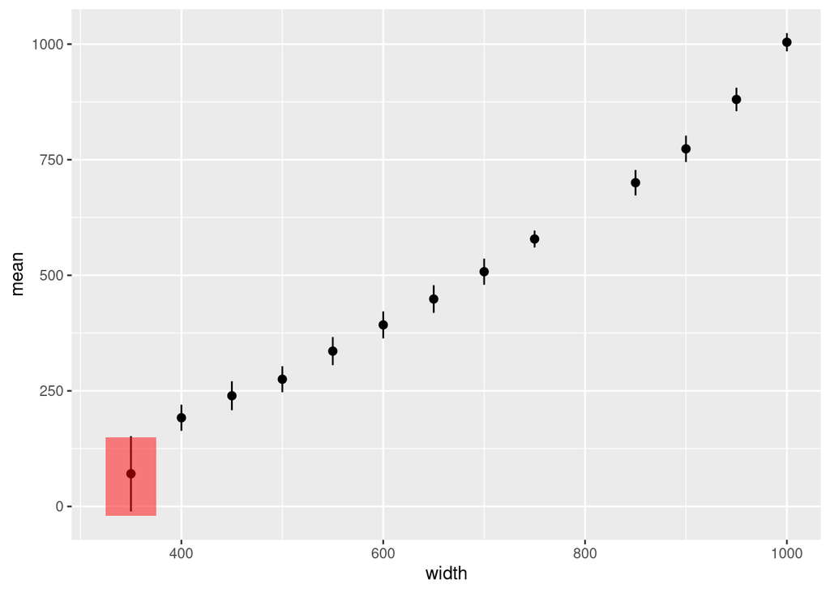

```r
medByPWidth = med %>% group_by(width) %>% summarise(mean = mean(Length),sd = sd(Length))
ggplot(medByPWidth,aes(width,mean)) + geom_point(size = 2) + geom_errorbar(aes(ymin=mean-sd, ymax=mean+sd), width = 0.05) +  geom_rect(aes(xmin = 325, xmax = 375, ymin = -20, ymax = 150),
            fill = "red", alpha = 0.05)
```

```r
medSelect = med[med$width > 350,]
leveneTest(medSelect$Length,medSelect$width)
```

```
## Levene's Test for Homogeneity of Variance (center = median)
##       Df F value Pr(>F)
## group 11  0.4321  0.938
##       96
```

As can be seen by the plot and explored by a model. The fabrication technique is fairly reproducible, yielding in comparable mean widths. The residuals didn’t have normal distribution so a Kruskal-Wallis test was applied

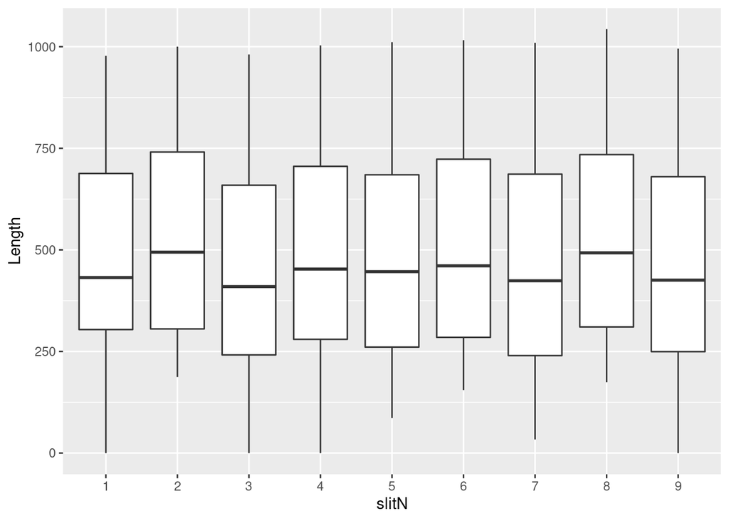

```r
ggplot(med,aes(slitN,Length)) + geom_boxplot()
```

```r
group = lm(Length ~ slitN,data = medSelect)
group %>% summary()
```

```
##
## Call:
## lm(formula = Length ~ slitN, data = medSelect)
##
## Residuals:
##     Min      1Q  Median      3Q     Max
## -353.87 -213.80  -49.07  195.57  500.53
##
## Coefficients:
##             Estimate Std. Error t value Pr(>|t|)
## (Intercept) 529.5995    76.2206   6.948 3.96e-10 ***
## slitN2       29.3332   107.7922   0.272    0.786
## slitN3      -43.4667   107.7922  -0.403    0.688
## slitN4        0.9332   107.7922   0.009    0.993
## slitN5      -10.4000   107.7922  -0.096    0.923
## slitN6        9.7332   107.7922   0.090    0.928
## slitN7      -20.5333   107.7922  -0.190    0.849
## slitN8       33.5999   107.7922   0.312    0.756
## slitN9      -19.3333   107.7922  -0.179    0.858
## ---
## Signif. codes:  0 '***' 0.001 '**' 0.01 '*' 0.05 '.' 0.1 ' ' 1
##
## Residual standard error: 264 on 99 degrees of freedom
## Multiple R-squared:  0.008333,   Adjusted R-squared:  -0.0718
## F-statistic: 0.104 on 8 and 99 DF,  p-value: 0.999
```

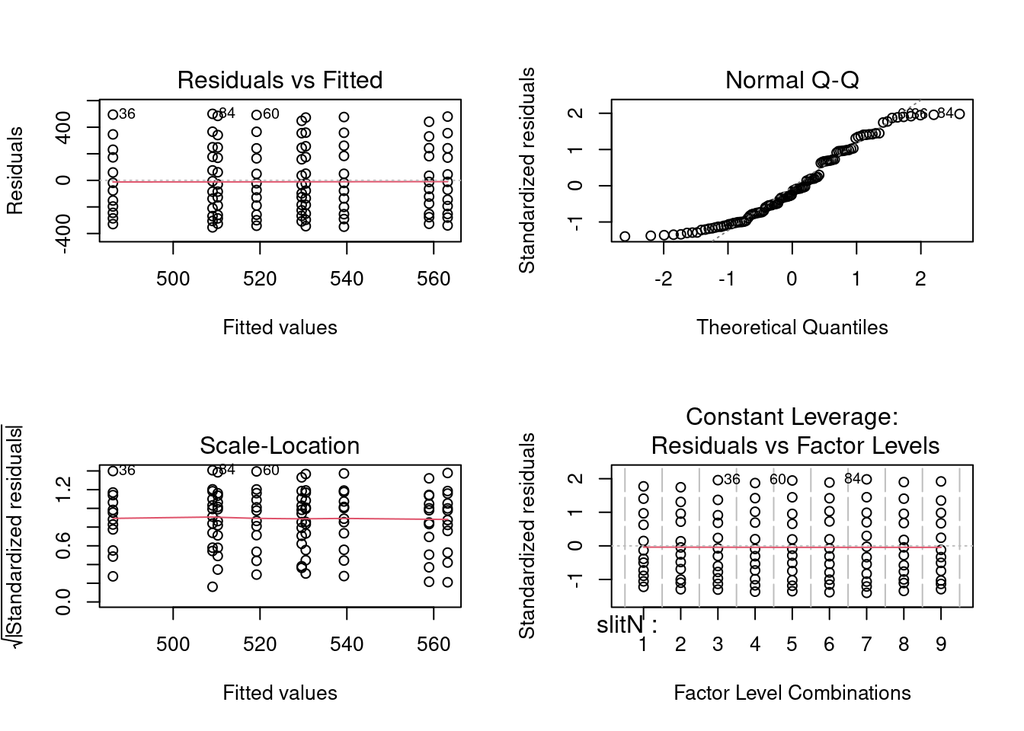

```r
par(mfrow =c(2,2) )
group %>% plot()
```

```r
shapiro.test(group$residuals)
```

```
##
##  Shapiro-Wilk normality test
##
## data:  group$residuals
## W = 0.9309, p-value = 2.876e-05
```

```r
group = kruskal.test(Length ~ slitN,data = medSelect)
group
```

```
##
##  Kruskal-Wallis rank sum test
##
## data:  Length by slitN
## Kruskal-Wallis chi-squared = 1.2705, df = 8, p-value = 0.9959
```

To assess the functional relation between the design specification and output, a series of linear models were built and evaluated. The final model was built using a 3rd degree polynomial because it met all assumptions of LM and had the lowest AIC.

first degree has a pattern in the residuals with a parabolic shape, indicating the need for a sqare term.

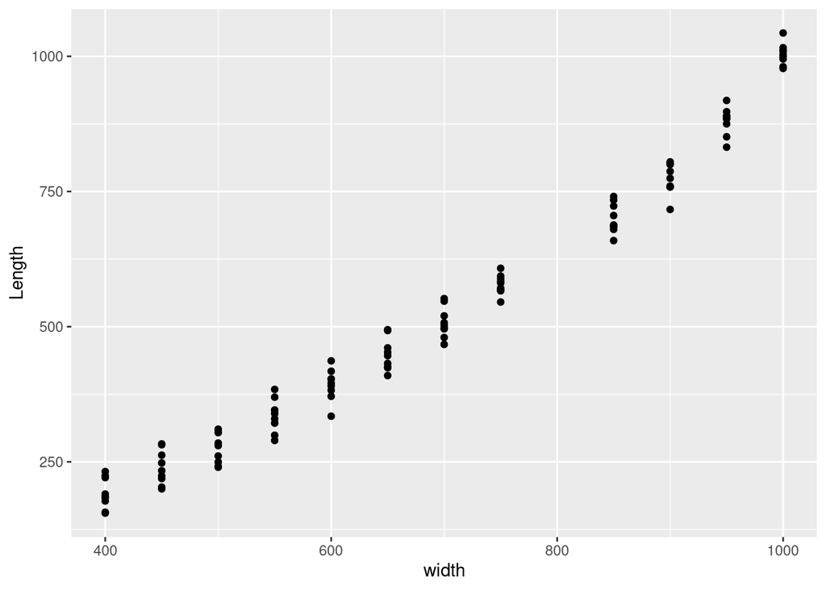

```r
ggplot(medSelect,aes(width,Length)) + geom_point()
```

```r
poly1 = lm(Length ~ poly(width,1),data = medSelect)
poly1 %>% summary()
```

```
##
## Call:
## lm(formula = Length ~ poly(width, 1), data = medSelect)
##
## Residuals:
##     Min      1Q  Median      3Q     Max
## -81.744 -32.894  -4.301  26.253 114.489
##
## Coefficients:
##                Estimate Std. Error t value Pr(>|t|)
## (Intercept)     527.362      4.038  130.60   <2e-16 ***
## poly(width, 1) 2602.522     41.962   62.02   <2e-16 ***
## ---
## Signif. codes:  0 '***' 0.001 '**' 0.01 '*' 0.05 '.' 0.1 ' ' 1
##
## Residual standard error: 41.96 on 106 degrees of freedom
## Multiple R-squared:  0.9732, Adjusted R-squared:  0.9729
## F-statistic:  3847 on 1 and 106 DF,  p-value: < 2.2e-16
```

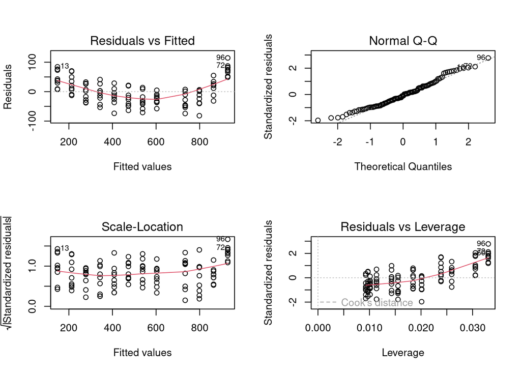

```r
par(mfrow =c(2,2) )
poly1 %>% plot()
```

In the case of the 2nd degree it exhibited an s shape parameter with 3 intercepts, indicating that a 3rd order term may be necesary.

```r
poly2 = lm(Length ~ poly(width,2),data = medSelect)
poly2 %>% summary()
```

```
##
## Call:
## lm(formula = Length ~ poly(width, 2), data = medSelect)
##
## Residuals:
##     Min      1Q  Median      3Q     Max
## -83.301 -21.165   0.785  20.523  66.217
##
## Coefficients:
##                 Estimate Std. Error t value Pr(>|t|)
## (Intercept)       527.36       2.84  185.66   <2e-16 ***
## poly(width, 2)1  2602.52      29.52   88.17   <2e-16 ***
## poly(width, 2)2   308.48      29.52   10.45   <2e-16 ***
## ---
## Signif. codes:  0 '***' 0.001 '**' 0.01 '*' 0.05 '.' 0.1 ' ' 1
##
## Residual standard error: 29.52 on 105 degrees of freedom
## Multiple R-squared:  0.9869, Adjusted R-squared:  0.9866
## F-statistic:  3941 on 2 and 105 DF,  p-value: < 2.2e-16
```

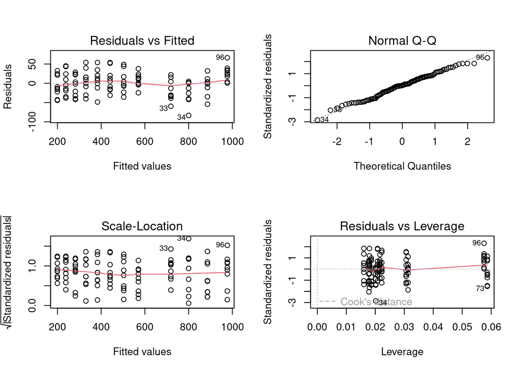

```r
par(mfrow =c(2,2) )
poly2 %>% plot()
```

Finally, we are there

```r
poly3 = lm(Length ~ poly(width,3),data = medSelect)
poly3 %>% summary()
```

```
##
## Call:
## lm(formula = Length ~ poly(width, 3), data = medSelect)
##
## Residuals:
##     Min      1Q  Median      3Q     Max
## -73.011 -19.415   1.357  18.066  50.710
##
## Coefficients:
##                 Estimate Std. Error t value Pr(>|t|)
## (Intercept)      527.362      2.689 196.099  < 2e-16 ***
## poly(width, 3)1 2602.522     27.948  93.121  < 2e-16 ***
## poly(width, 3)2  308.475     27.948  11.038  < 2e-16 ***
## poly(width, 3)3  101.299     27.948   3.625  0.00045 ***
## ---
## Signif. codes:  0 '***' 0.001 '**' 0.01 '*' 0.05 '.' 0.1 ' ' 1
##
## Residual standard error: 27.95 on 104 degrees of freedom
## Multiple R-squared:  0.9883, Adjusted R-squared:  0.988
## F-statistic:  2936 on 3 and 104 DF,  p-value: < 2.2e-16
```

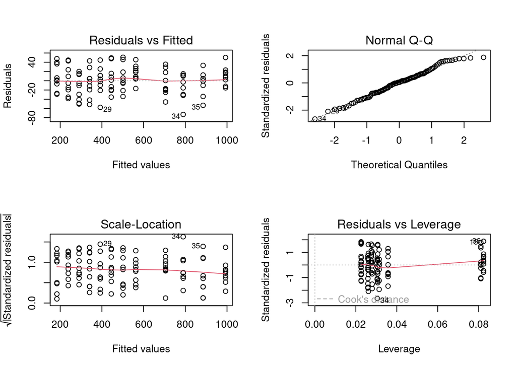

```r
par(mfrow =c(2,2) )
poly3 %>% plot()
```

```r
poly3$residuals %>% leveneTest(medSelect$width)
```

```
## Levene's Test for Homogeneity of Variance (center = median)
##       Df F value Pr(>F)
## group 11  0.4321  0.938
##       96
```

```r
poly3$residuals %>% shapiro.test()
```

```
##
##  Shapiro-Wilk normality test
##
## data:  .
## W = 0.9852, p-value = 0.2774
```

```r
AIC(poly1,poly2,poly3)
```

```
##       df      AIC
## poly1  3 1117.615
## poly2  4 1042.614
## poly3  5 1031.767
```

Now, the reverse model is built to predict the design specification needed to achieve a desired width. Despite the model has a standard error of prediction of 22.22 um, the experimental data suggest that that may be an overly optimistic estimate.

```r
reversed = lm(width ~ poly(Length,3),data = medSelect)
reversed %>% summary()
```

```
##
## Call:
## lm(formula = width ~ poly(Length, 3), data = medSelect)
##
## Residuals:
##     Min      1Q  Median      3Q     Max
## -52.208 -12.127   0.378  13.262  55.424
##
## Coefficients:
##                  Estimate Std. Error t value Pr(>|t|)
## (Intercept)       691.667      2.138  323.51  < 2e-16 ***
## poly(Length, 3)1 1972.383     22.219   88.77  < 2e-16 ***
## poly(Length, 3)2 -228.442     22.219  -10.28  < 2e-16 ***
## poly(Length, 3)3  -60.653     22.219   -2.73  0.00744 **
## ---
## Signif. codes:  0 '***' 0.001 '**' 0.01 '*' 0.05 '.' 0.1 ' ' 1
##
## Residual standard error: 22.22 on 104 degrees of freedom
## Multiple R-squared:  0.9872, Adjusted R-squared:  0.9868
## F-statistic:  2664 on 3 and 104 DF,  p-value: < 2.2e-16
```

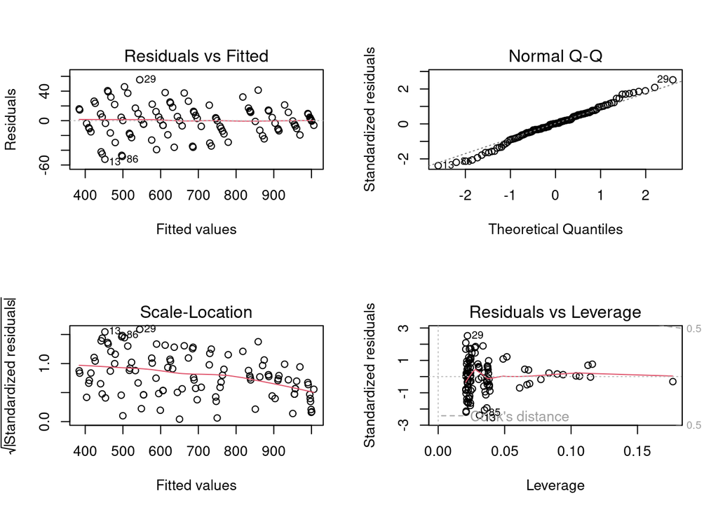

```r
par(mfrow =c(2,2) )
reversed %>% plot()
```

To avoid being too close to the lowest value and taking into account the standard error, a width that has good chances of working could be a value in between those resulting for a specification of 400 um and 450 um. The resulting specification will be 424 um

```r
aim = medSelect[medSelect$width < 451,1] %>% unlist() %>% mean()
predict(reversed,tibble(Length = 200)) %>% round()
```

```
##   1
## 424
```